# Fetal Center Data Exercise

Eric Bergh, MD

2023-02-15

## Exercise

### Referral Counts

##### The following datasets are in the attached email:

- test_data.csv
  - patient IDs have been removed and replaced with anonymous IDs
  - each row is a patient
  - demographic data is located on rows were redcap_event_name = ‘demographic_data_arm_1’
  - operative data is located on rows were redcap_event_name = ‘operative_data_arm_1’
  - rows repeat if the patient had multiple procedures
  - dates have been shifted to preserve anonymity
  - **[demo_ref_doc]** is the referring doctor ID for each practice
  - **[demo_exam_date]** is the date of referral for each patient
  - you may assume that any procedures were performed at the same time as the referral (procedure date = **[demo_exam_date]**)
- test_practice_database.csv
  - has information on referring doc and geo-location of practice
  - **[ref_state]** is the state where the referring physician is located
  - **[ref_geo_area]** is the geographic area where the referring physician is located
  - **[ref_practice_doc]** is the ID for the referring physician at that practice
  - **[demo_ref_doc]** in the “test_data.csv” database is **EQUIVALENT** to **[ref_practice_doc]** in “test_practice_database.csv”)

##### Here is an example, in which each facet is a different state, and the color represents the ‘geographic area’ **[ref_geo_area]**

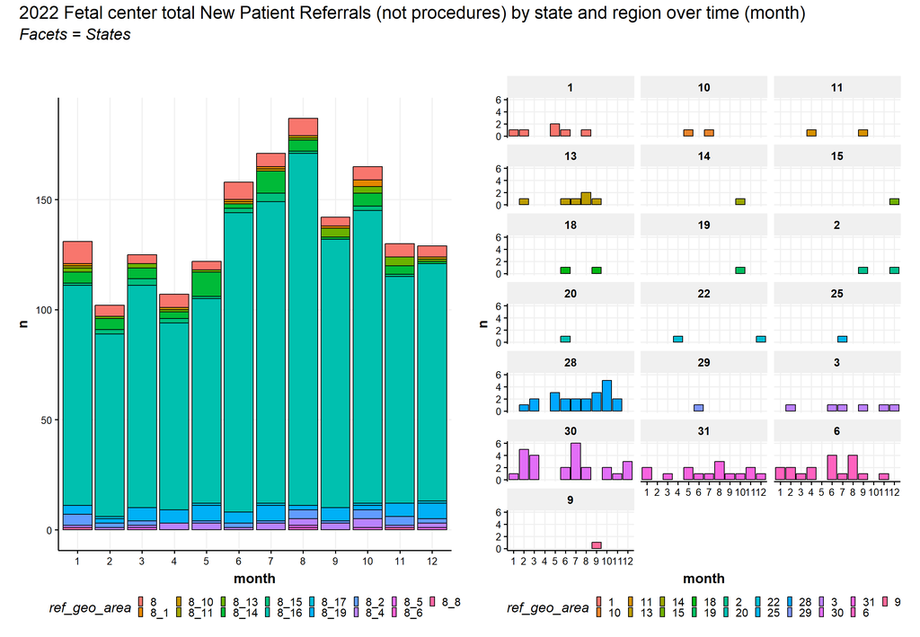

### Procedure Counts:

The following are types of procedures performed in the Fetal Center (not all are included in the dataset):

```r
procedures <- c("laser", # fetoscopic laser for twin-twin transfusion
                "vasa_previa", # laser ablation of vasa previa
                "bipolar_rfa", # bipolar cord coagulation / radiofrequency ablation
                "chorioangioma", # treatment of placental chorioangioma
                "abs", # treatment of amniotic band syndrome
                "feto", # fetoscopic endoluminal tracheal occlusion
                "exit", # ex-uterio intrapartum treatment procedure
                "shunt", # vesicoamniotic OR thoracoamniotic shunt placement
                "ntd", # fetal spina bifida surgery
                "iut", # intrauterine transfusion
                "minor_proc") # minor needle based procedure
```

Data for procedures is located in individual columns, all which begin with “procedure_”

You may assume that any procedures (even repeat procedures) were performed at the same time as the referral (procedure date = **[demo_exam_date]**)

**EXERCISE: Please create table of procedure counts over time (month) for the entire dataset. For each state which has referred a patient with a procedure, please create a separate table.**

- You may include a visualization as well if you feel this will add to the understanding.